# ARIMA and Seasonal ARIMA

## Autoregressive Integrated Moving Averages

The general process for ARIMA models is the following:

• Visualize the Time Series Data

• Make the time series data stationary

• Plot the Correlation and AutoCorrelation Charts

• Construct the ARIMA Model or Seasonal ARIMA based on the data

• Use the model to make predictions

Let's go through these steps!

```python
import numpy as np
import pandas as pd

import matplotlib.pyplot as plt
%matplotlib inline
```

```python
df=pd.read_csv('electric_dept_dataset.csv')
```

```python
df.head()
```

|  | Month | Electricity Consumption Delhi (G) |
| --- | --- | --- |
| 0 | 1964-01 | 2815 |
| 1 | 1964-02 | 2672 |
| 2 | 1964-03 | 2755 |
| 3 | 1964-04 | 2721 |
| 4 | 1964-05 | 2946 |

```python
df.tail()
```

|  | Month | Electricity Consumption Delhi (G) |
| --- | --- | --- |
| 100 | 1972-05 | 4618 |
| 101 | 1972-06 | 5312 |
| 102 | 1972-07 | 4298 |
| 103 | 1972-08 | 1413 |
| 104 | 1972-09 | 5877 |

```python
## Cleaning up the data
df.columns=["Month","Sales"]
df.head()
```

|  | Month | Sales |
| --- | --- | --- |
| 0 | 1964-01 | 2815 |
| 1 | 1964-02 | 2672 |
| 2 | 1964-03 | 2755 |
| 3 | 1964-04 | 2721 |
| 4 | 1964-05 | 2946 |

```python
df.tail()
```

|  | Month | Sales |
| --- | --- | --- |
| 100 | 1972-05 | 4618 |
| 101 | 1972-06 | 5312 |
| 102 | 1972-07 | 4298 |
| 103 | 1972-08 | 1413 |
| 104 | 1972-09 | 5877 |

```python
# Convert Month into Datetime
df['Month']=pd.to_datetime(df['Month'])
```

```python
df.head()
```

|  | Month | Sales |
| --- | --- | --- |
| 0 | 1964-01-01 | 2815 |
| 1 | 1964-02-01 | 2672 |
| 2 | 1964-03-01 | 2755 |
| 3 | 1964-04-01 | 2721 |
| 4 | 1964-05-01 | 2946 |

```python
df.set_index('Month',inplace=True)
```

```python
df.head()
```

| Month | Sales |
| --- | --- |
| 1964-01-01 | 2815 |
| 1964-02-01 | 2672 |
| 1964-03-01 | 2755 |
| 1964-04-01 | 2721 |
| 1964-05-01 | 2946 |

```python
df.describe()
```

|  | Sales |
| --- | --- |
| count | 105.000000 |
| mean | 4761.152381 |
| std | 2553.502601 |
| min | 1413.000000 |
| 25% | 3113.000000 |
| 50% | 4217.000000 |
| 75% | 5221.000000 |
| max | 13916.000000 |

## Visualizing the Data

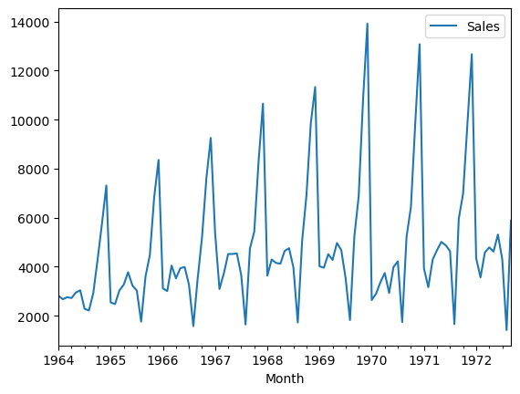

```python
df.plot()
```

```python
### Testing For Stationarity

from statsmodels.tsa.stattools import adfuller
```

```python
test_result=adfuller(df['Sales'])
```

```python
#Ho: It is non stationary
#H1: It is stationary

def adfuller_test(sales):
    result=adfuller(sales)
    labels = ['ADF Test Statistic','p-value','#Lags Used','Number of Observations Used']
    for value,label in zip(result,labels):
        print(label+' : '+str(value) )
    if result[1] <= 0.05:
        print("strong evidence against the null hypothesis(Ho), reject the null hypothesis. Data has no unit root and is stationary")
    else:
        print("weak evidence against null hypothesis, time series has a unit root, indicating it is non-stationary ")
```

```python
adfuller_test(df['Sales'])
```

```
ADF Test Statistic : -1.833593056327616
p-value : 0.3639157716602485
#Lags Used : 11
Number of Observations Used : 93
weak evidence against null hypothesis, time series has a unit root, indicating it is non-stationary
```

### Differencing

```python
df['Sales First Difference'] = df['Sales'] - df['Sales'].shift(1)
```

```python
df['Sales'].shift(1)
```

```
Month
1964-01-01       NaN
1964-02-01    2815.0
1964-03-01    2672.0
1964-04-01    2755.0
1964-05-01    2721.0
               ...
1972-05-01    4788.0
1972-06-01    4618.0
1972-07-01    5312.0
1972-08-01    4298.0
1972-09-01    1413.0
Name: Sales, Length: 105, dtype: float64
```

```python
df['Seasonal First Difference']=df['Sales']-df['Sales'].shift(12)
```

```python
df.head(14)
```

| Month | Sales | Sales First Difference | Seasonal First Difference |
| --- | --- | --- | --- |
| 1964-01-01 | 2815 | NaN | NaN |
| 1964-02-01 | 2672 | -143.0 | NaN |
| 1964-03-01 | 2755 | 83.0 | NaN |
| 1964-04-01 | 2721 | -34.0 | NaN |
| 1964-05-01 | 2946 | 225.0 | NaN |
| 1964-06-01 | 3036 | 90.0 | NaN |
| 1964-07-01 | 2282 | -754.0 | NaN |
| 1964-08-01 | 2212 | -70.0 | NaN |
| 1964-09-01 | 2922 | 710.0 | NaN |
| 1964-10-01 | 4301 | 1379.0 | NaN |
| 1964-11-01 | 5764 | 1463.0 | NaN |
| 1964-12-01 | 7312 | 1548.0 | NaN |
| 1965-01-01 | 2541 | -4771.0 | -274.0 |
| 1965-02-01 | 2475 | -66.0 | -197.0 |

```python
## Again test dickey fuller test

adfuller_test(df['Seasonal First Difference'].dropna())
```

```
ADF Test Statistic : -7.626619157213164
p-value : 2.060579696813685e-11
#Lags Used : 0
Number of Observations Used : 92
strong evidence against the null hypothesis(Ho), reject the null hypothesis. Data has no unit root and is stationary
```

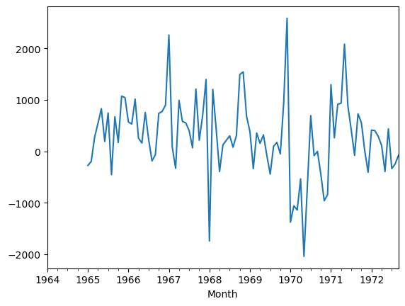

```python
df['Seasonal First Difference'].plot()
```

## Auto Regressive Model

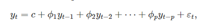

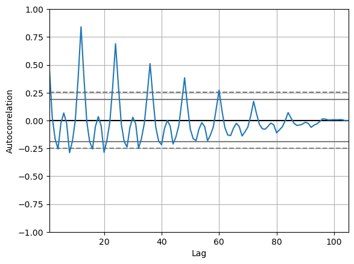

```python
from pandas.plotting import autocorrelation_plot
import matplotlib.pyplot as plt

autocorrelation_plot(df['Sales'])
plt.show()
```

### Final Thoughts on Autocorrelation and Partial Autocorrelation

• Identification of an AR model is often best done with the PACF.

• For an AR model, the theoretical PACF “shuts off” past the order of the model. The phrase “shuts off” means that in theory the partial autocorrelations are equal to 0 beyond that point. Put another way, the number of non-zero partial autocorrelations gives the order of the AR model. By the “order of the model” we mean the most extreme lag of x that is used as a predictor.

• Identification of an MA model is often best done with the ACF rather than the PACF.

• For an MA model, the theoretical PACF does not shut off, but instead tapers toward 0 in some manner. A clearer pattern for an MA model is in the ACF. The ACF will have non-zero autocorrelations only at lags involved in the model.

p,d,q p AR model lags d differencing q MA lags

```python
from statsmodels.graphics.tsaplots import plot_acf,plot_pacf
```

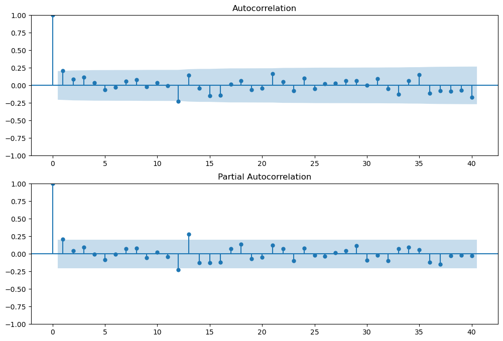

```python
import matplotlib.pyplot as plt
import statsmodels.api as sm

fig = plt.figure(figsize=(12, 8))

# First subplot (ACF)
ax1 = fig.add_subplot(211)
sm.graphics.tsa.plot_acf(df['Seasonal First Difference'].iloc[13:], lags=40, ax=ax1)

# Second subplot (PACF)
ax2 = fig.add_subplot(212)
sm.graphics.tsa.plot_pacf(df['Seasonal First Difference'].iloc[13:], lags=40, ax=ax2)

plt.show()
```

```python
# For non-seasonal data
#p=1, d=1, q=0 or 1
from statsmodels.tsa.arima_model import ARIMA
```

```python
import statsmodels.api as sm

# Define the ARIMA model with order=(1, 1, 1)
model = sm.tsa.ARIMA(df['Sales'], order=(1, 1, 1))

# Fit the model
model_fit = model.fit()

# Print summary information
model_fit.summary()
```

SARIMAX Results

| Dep. Variable: | Sales | No. Observations: | 105 |
| --- | --- | --- | --- |
| Model: | ARIMA(1, 1, 1) | Log Likelihood | -952.814 |
| Date: | Wed, 06 Dec 2023 | AIC | 1911.627 |
| Time: | 18:04:33 | BIC | 1919.560 |
| Sample: | 01-01-1964 | HQIC | 1914.841 |
|  | - 09-01-1972 |  |  |
| Covariance Type: | opg |  |  |

|  | coef | std err | z | P>\|z\| | [0.025 | 0.975] |
| --- | --- | --- | --- | --- | --- | --- |
| ar.L1 | 0.4545 | 0.114 | 3.999 | 0.000 | 0.232 | 0.677 |
| ma.L1 | -0.9666 | 0.056 | -17.316 | 0.000 | -1.076 | -0.857 |
| sigma2 | 5.226e+06 | 6.17e+05 | 8.473 | 0.000 | 4.02e+06 | 6.43e+06 |

| Ljung-Box (L1) (Q): | 0.91 | Jarque-Bera (JB): | 2.59 |
| --- | --- | --- | --- |
| Prob(Q): | 0.34 | Prob(JB): | 0.27 |
| Heteroskedasticity (H): | 3.40 | Skew: | 0.05 |
| Prob(H) (two-sided): | 0.00 | Kurtosis: | 3.77 |

Warnings:  
[1] Covariance matrix calculated using the outer product of gradients (complex-step).

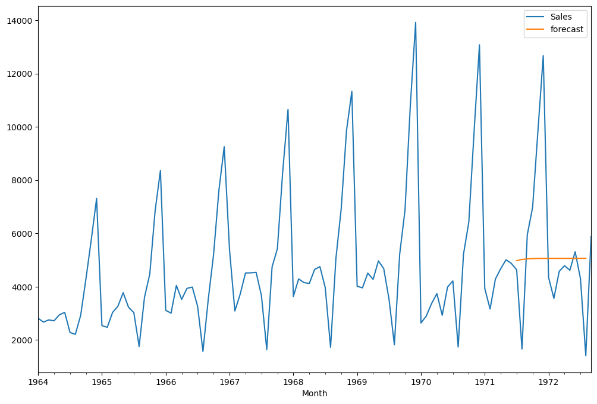

```python
df['forecast']=model_fit.predict(start=90,end=103,dynamic=True)
df[['Sales','forecast']].plot(figsize=(12,8))
```